# Project-1

Hannes Gubler

21 May, 2023

# 1 Introduction

In this report, we work with binned data where each bin refers to a diameter range of snowflakes. More precisely, it contains the total number of snowflakes measured and the percentage of snowflakes belonging to each diameter bin. The data comes from the Laboratory of Cryospheric sciences at EPFL. Expert knowledge suggests that a mixture of two log-normal distributions (bi-log-normal distribution) is a good model for the data.

The outline of the remainder of this report is as follows: In Section (2), we visually verify whether the expert knowledge of a bi-log-normal distribution is a valid assumption. After that, in Section (3), we will use the EM algorithm and an optimization algorithm to estimate the five parameters that describe the bi-log-normal distribution. Finally, in Section (4), we will use parametric bootstrap to test whether the snowflake diameters come from a bi-log-normal distribution.

# 2 Descriptive Data Exploration

Since we already have access to the expert knowledge telling us that the bi-log-normal distribution is a good model for the data, our main goal in this section is to check whether this is a viable assumption. It would be easy to just plot a histogram of the data, but as we only have the data in bins of different sizes, it will be slightly more difficult. So before plotting the histogram in Figure (2.1), we jitter the data using a uniform distribution inside each bin. Also, we set the endpoint of the last bin to 3.25 to make the size of the last bin more comparable to the other bins (the last bin does not contain any datapoint so this will not affect our future calculations).

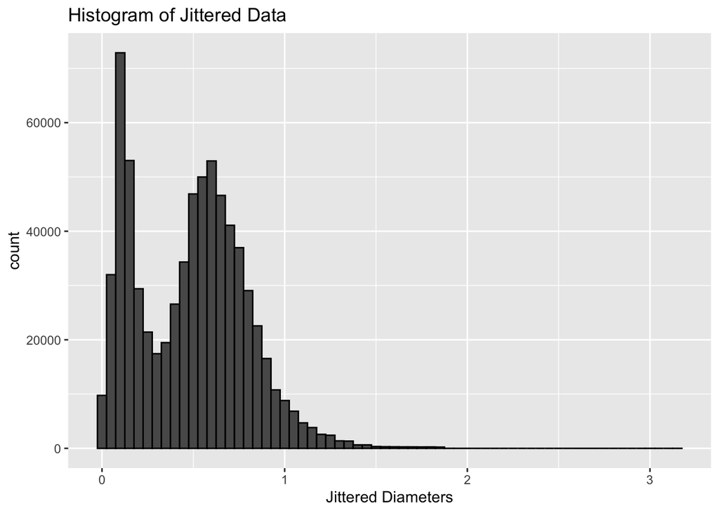

Figure 2.1: Histogram of the snowflake diameters after jittering the data using a uniform distribution in each bin.

We can see that the assumption of a bi-log-normal distribution seems valid as we have two bumps that are slightly right scewed, as we would expect from a mixture of two log-normal distributions.

# 3 Parameter estimation

In this section, we estimate the parameters for the jittered data assuming it follows a bi-log-normal distribution. We proceed as follows: First, using the EM algorithm, we estimate the parameters $\mu_1, \mu_2, \sigma_1, \sigma_2$ and $\tau$ for the jittered data. After that, we optimize the log likelihood of the binned data (not the jittered data we use for the EM algorithm) starting with the values given by the EM algorithm.

## 3.1 EM algorithm

To estimate the parameters using the EM algorithm, we have to set a starting value for each parameter $\mu_1, \mu_2, \sigma_1, \sigma_2$ and $\tau$. Hence it is useful to look back on our histogram in Figure (2.1). Since the expectation and variance of a log-normal distribution with parameters $\mu, \sigma$ are given by $\exp(\mu + \frac{\sigma^2}{2})$ and $(\exp(\sigma^2)-1)\exp(2\mu+\sigma^2)$, we set our starting values to $\mu_1 = -3, \mu_2 = -0.5, \sigma_1 = 0.3, \sigma_2 = 0.4$ and $\tau = 0.7$. We will use the estimates of the EM algorithm in the next section to optimize the likelihood of the binned data. For now, the estimates of the EM algorithm give us another opportunity to check the assumption of a bi-log-normal model: We can create a plot with the kernel density estimator (Gaussian kernel) of the jittered data and the density of a bi-log-normal distribution parametrized by the estimates of the EM algorithm.

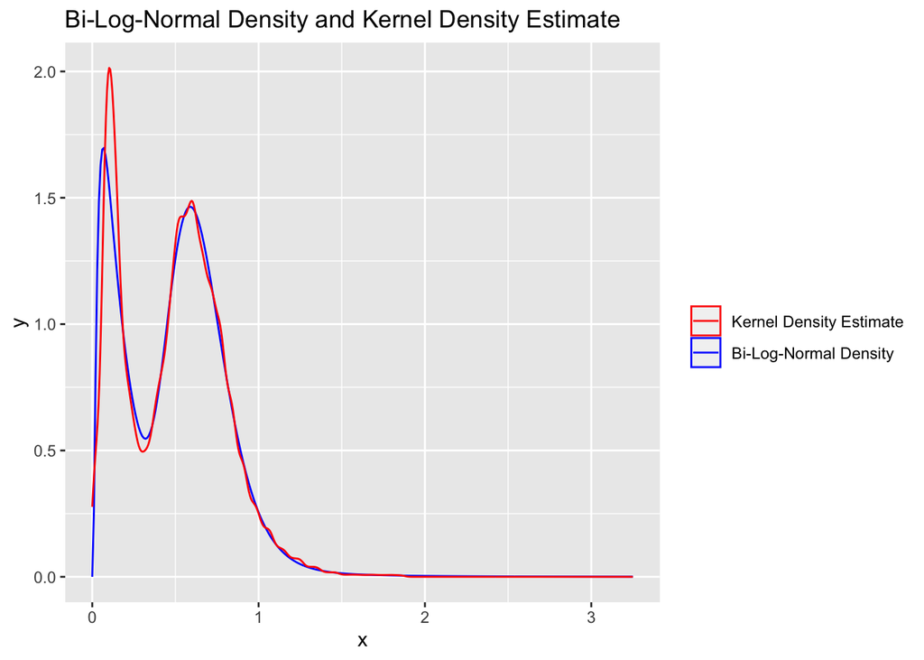

Figure 3.1: Kernel density estimate (Gaussian kernel) of the jittered data together with the density of the bi-log-normal model parametrized by the estimates of the EM algorithm applied to the jittered data.

We observe two very similar curves, supporting our assumption of the bi-log-normal model. This plot is also useful to see that the EM algorithm converged to a reasonable solution.

## 3.2 Optimization

Since we performed the EM algorithm on the jittered data, we did not maximize the true log-likelihood of the binned data. The log likelihood of the binned data is given by
$$f(d\mid\mu_1, \mu_2,\sigma_1, \sigma_2, \tau) \propto \prod_{j=1}^n \left[ \Phi_{\mu_1, \mu_2,\sigma_1, \sigma_2, \tau}(a_{j}) - \Phi_{\mu_1, \mu_2,\sigma_1, \sigma_2, \tau}(a_{j-1}) \right]^{b_j},$$
where $a_j$ are the bin endpoints, $b_j$ the frequencies observed for each bin, $\Phi$ is the CDF of the bi-log-normal distribution and $d$ is the full dataset.

Even tough the estimates from the EM algorithm in Section (3.1) are for the jittered data, the results should be close to the MLE of the binned log likelihood, hence we can use them as starting values to perform an optimization on the binned log likelihood. We use the Nelder-Mead optimization algorithm.

The estimates we obtain by optimizing the binned log likelihood are displayed in Table (3.1).

Table 3.1: Parameter estimates obtained by optimizing the binned log likelihood using the results of the EM algorithm on the jittered data as starting point.

| Name | Value |
| --- | --- |
| $\mu_1$ | -2.019 |
| $\mu_2$ | -0.455 |
| $\sigma_1$ | 0.605 |
| $\sigma_2$ | 0.302 |
| $\tau$ | 0.651 |

So far we have only seen visual evidence that the data could follow a bi-log-normal distribution. Section (4) will be dedicated to statistically test this assumption, using parametric bootstrap.

# 4 Parametric Bootstrap

In this section we test whether our data supports the hypothesis if its distribution, say $F$, belongs to the parametric family of bi-log-normal distributions, say $\mathcal{F}$. So we formulate $H_0$ and $H_1$ as
$$H_0: F \in \mathcal{F},\qquad H_1: F \notin \mathcal{F}.$$
To perform this test, we proceed as follows: We create $B$ bootstrap datasets containing 705044 datapoints (same number as original dataset) by sampling from a bi-log-normal distribution using the optimized parameters from before. After that, for each bootstrap dataset, we perform the following steps.

1. Bin the data using the bins of the original dataset.
2. Jitter the data in the same way as we did with the original dataset.
3. Estimate the parameters of the bi-log-normal model using the EM algorithm on the jittered data.
4. Optimize the log likelihood of the binned data.

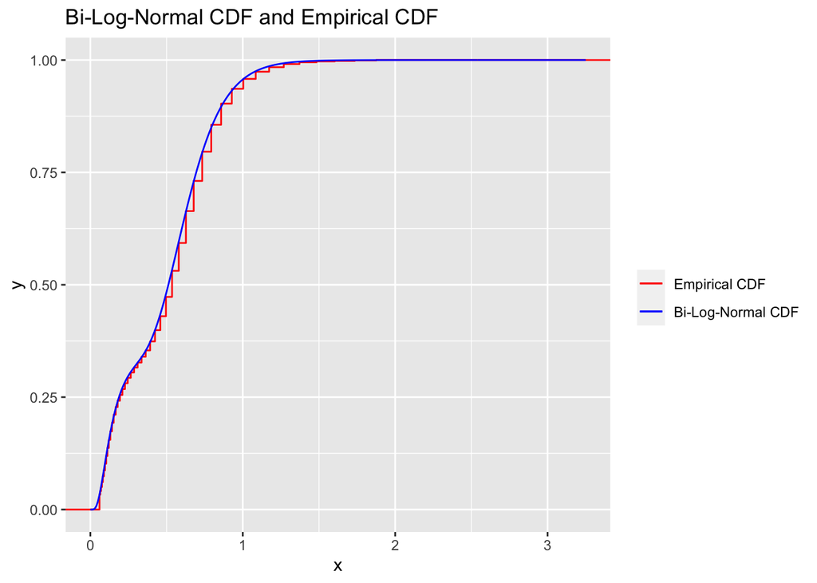

Figure 4.1: Empirical CDF of the original binned data with a bi-log-normal CDF parametrized by our optimized parameters.

We see that a bi-log-normal distribution parametrized by our optimized parameters is a very good model for the binned data.

# 5 Conclusion

The steps in this report show that even if we only have access to binned data there are possibilities to find an appropriate statistical model for the data. However, this requires some extra steps and we would always prefer non-binned data as it provides more information.